# Jessica Qin Final Project

# Gathering Data

The data is from the World Happiness Report which consists of a Positive Affect attribute (which represents happiness, laughter, and enjoyment), a Negative Affect attribute (which represents worry, sadness, and anger) as well as various other attributes relevant to the country’s government and social aspects throughout various years.

Attributes:

Country

Year

Life Expectancy

Freedom: Average of Binary response (1 = satisfied or 0 = dissatisfied) to the question “Are you satisfied or dissatisfied with your freedom to choose what you do with your life”

Generosity: The residual of regressing national average of reponse to “Have you donated money to a charity in the past month?” on GDP per capita

Corruption: Average of Binary response (1 = yes or 0 = no) to the question “Is corruption widespread throughout the government or not” and “Is corruption widespread within businesses or not?”

Positive Affect: Average binary answers to “Did you experience a lot of happiness today?” and “DId you smile or laugh a lot yesterday?”

Negative Affect: Average binary answers to “Did you experience a lot of sadness today?” and “Did you experience a lot of these feelings yesterday?”

```r
library(tidyverse)
df <- read_csv("happiness.csv")
select_df <- df %>%
  select(`Country name`,Year,`Healthy life expectancy at birth`, `Freedom to make life choices`, `Perceptions of corruption`, Generosity, `Positive affect`, `Negative affect`)

colnames(select_df) <- c("Country", "Year", "life_exp", "Freedom", "Corruption", "Generosity", "positive_affect", "negative_affect")

select_df
```

| Country | Year | life_exp | Freedom | Corruption | Generosity | positive_affect | negative_affect |
| --- | --- | --- | --- | --- | --- | --- | --- |
| Afghanistan | 2008 | 50.80000 | 0.7181143 | 0.88168633 | 0.1778885720 | 0.5176372 | 0.25819549 |
| Afghanistan | 2009 | 51.20000 | 0.6788964 | 0.85003543 | 0.2001784290 | 0.5839256 | 0.23709242 |
| Afghanistan | 2010 | 51.60000 | 0.6001272 | 0.70676607 | 0.1343525500 | 0.6182654 | 0.27532381 |
| Afghanistan | 2011 | 51.92000 | 0.4959014 | 0.73110855 | 0.1721366640 | 0.6113873 | 0.26717469 |
| Afghanistan | 2012 | 52.24000 | 0.5309350 | 0.77561981 | 0.2442727240 | 0.7103847 | 0.26791912 |
| Afghanistan | 2013 | 52.56000 | 0.5779554 | 0.82320410 | 0.0704026590 | 0.6205848 | 0.27332810 |
| Afghanistan | 2014 | 52.88000 | 0.5085140 | 0.87124199 | 0.1131844820 | 0.5316915 | 0.37486073 |
| Afghanistan | 2015 | 53.20000 | 0.3889276 | 0.88063830 | 0.0890906750 | 0.5535532 | 0.33927605 |
| Afghanistan | 2016 | 53.00000 | 0.5225662 | 0.79324555 | 0.0513649170 | 0.5649527 | 0.34833229 |
| Afghanistan | 2017 | 52.80000 | 0.4270109 | 0.95439255 | -0.1121982860 | 0.4963486 | 0.37132618 |

[output cut: 1694 more lines]

# Tidying Data

There’s a lot of missing data in this dataset for various reasons. There are a handful of countries that are missing values for Freedom and Corruption, this is usually for countries that are ruled under a dictatorship so the reason behind the missing data makes sense beause these countries most likely do not want it broadcasted that their citizens do not believe they have any freedom or that they feel the government is corrupted.

```r
select_df <- select_df %>%
  group_by(Country)%>%
  mutate(Freedom = ifelse(is.na(Freedom), mean(Freedom, na.rm = TRUE), Freedom))

select_df <- select_df %>%
  group_by(Country)%>%
  mutate(Generosity = ifelse(is.na(Generosity), mean(Generosity, na.rm = TRUE), Generosity))

select_df <- select_df %>%
  group_by(Country)%>%
  mutate(positive_affect = ifelse(is.na(positive_affect), mean(positive_affect, na.rm = TRUE), positive_affect))

select_df <- select_df %>%
  group_by(Country)%>%
  mutate(negative_affect = ifelse(is.na(negative_affect), mean(negative_affect, na.rm = TRUE), negative_affect))

select_df <- select_df %>%
  group_by(Country)%>%
  mutate(Corruption = ifelse(is.na(Corruption), mean(Generosity, na.rm = TRUE), Corruption)) %>%
  mutate(Corruption = ifelse(Corruption < 0, 0.5, Corruption))

select_df
```

| Country | Year | life_exp | Freedom | Corruption | Generosity | positive_affect | negative_affect |
| --- | --- | --- | --- | --- | --- | --- | --- |
| Afghanistan | 2008 | 50.80000 | 0.7181143 | 0.88168633 | 0.1778885720 | 0.5176372 | 0.25819549 |
| Afghanistan | 2009 | 51.20000 | 0.6788964 | 0.85003543 | 0.2001784290 | 0.5839256 | 0.23709242 |
| Afghanistan | 2010 | 51.60000 | 0.6001272 | 0.70676607 | 0.1343525500 | 0.6182654 | 0.27532381 |
| Afghanistan | 2011 | 51.92000 | 0.4959014 | 0.73110855 | 0.1721366640 | 0.6113873 | 0.26717469 |
| Afghanistan | 2012 | 52.24000 | 0.5309350 | 0.77561981 | 0.2442727240 | 0.7103847 | 0.26791912 |
| Afghanistan | 2013 | 52.56000 | 0.5779554 | 0.82320410 | 0.0704026590 | 0.6205848 | 0.27332810 |
| Afghanistan | 2014 | 52.88000 | 0.5085140 | 0.87124199 | 0.1131844820 | 0.5316915 | 0.37486073 |
| Afghanistan | 2015 | 53.20000 | 0.3889276 | 0.88063830 | 0.0890906750 | 0.5535532 | 0.33927605 |
| Afghanistan | 2016 | 53.00000 | 0.5225662 | 0.79324555 | 0.0513649170 | 0.5649527 | 0.34833229 |
| Afghanistan | 2017 | 52.80000 | 0.4270109 | 0.95439255 | -0.1121982860 | 0.4963486 | 0.37132618 |

[output cut: 1694 more lines]

# Top 10 most powerful countries

According to https://www.usnews.com/news/best-countries/power-rankings

```r
country_df <- select_df %>%
  filter(Year >= 2010) %>%
  filter( Country == "United States" | Country == "Russia" | Country == "China" | Country == "Germany" | Country == "United Kingdom" | Country == "France" | Country == "Japan" | Country == "Israel" | Country == "Saudi Arabia" | Country == "South Korea")

country_df
```

| Country | Year | life_exp | Freedom | Corruption | Generosity | positive_affect | negative_affect |
| --- | --- | --- | --- | --- | --- | --- | --- |
| China | 2010 | 67.60 | 0.8047936 | 0.5000000 | -0.148573548 | 0.7652646 | 0.1580997 |
| China | 2011 | 67.76 | 0.8241624 | 0.5000000 | -0.201895729 | 0.8200738 | 0.1335035 |
| China | 2012 | 67.92 | 0.8082551 | 0.5000000 | -0.200404897 | 0.8207849 | 0.1587030 |
| China | 2013 | 68.08 | 0.8047239 | 0.5000000 | -0.173714548 | 0.8364307 | 0.1422111 |
| China | 2014 | 68.24 | 0.8298932 | 0.5000000 | -0.232826754 | 0.8539750 | 0.1115177 |
| China | 2015 | 68.40 | 0.8298932 | 0.5000000 | -0.260586292 | 0.8089109 | 0.1713150 |
| China | 2016 | 68.70 | 0.8298932 | 0.5000000 | -0.243756711 | 0.8261444 | 0.1456252 |
| China | 2017 | 69.00 | 0.8776176 | 0.5000000 | -0.191224813 | 0.8210973 | 0.2140048 |
| China | 2018 | 69.30 | 0.8953777 | 0.5000000 | -0.174899161 | 0.8557839 | 0.1896398 |
| France | 2010 | 72.20 | 0.8497022 | 0.6229542 | -0.108059548 | 0.7897241 | 0.2605681 |

[output cut: 80 more lines]

# Looking for Trends

Here I plot Positive Affect vs Years to see if there is a trend in happiness

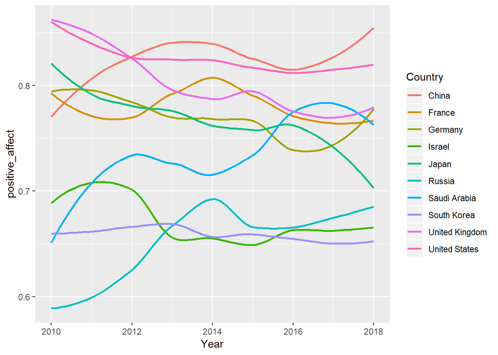

```r
country_df %>%
  ggplot(mapping = aes(x = Year, y = positive_affect, group_by(Year), color = Country)) +
  geom_smooth(size = 1, se = FALSE)
```

There appears to be no common trend for the 10 most powerful countries, a lot of the very developed countries such as Germany, Japan, South Korea, and the United States have slighlty declined throughout the years. Its mainly the currently developing countries that experience an increase in happiness.

Developed Countries:

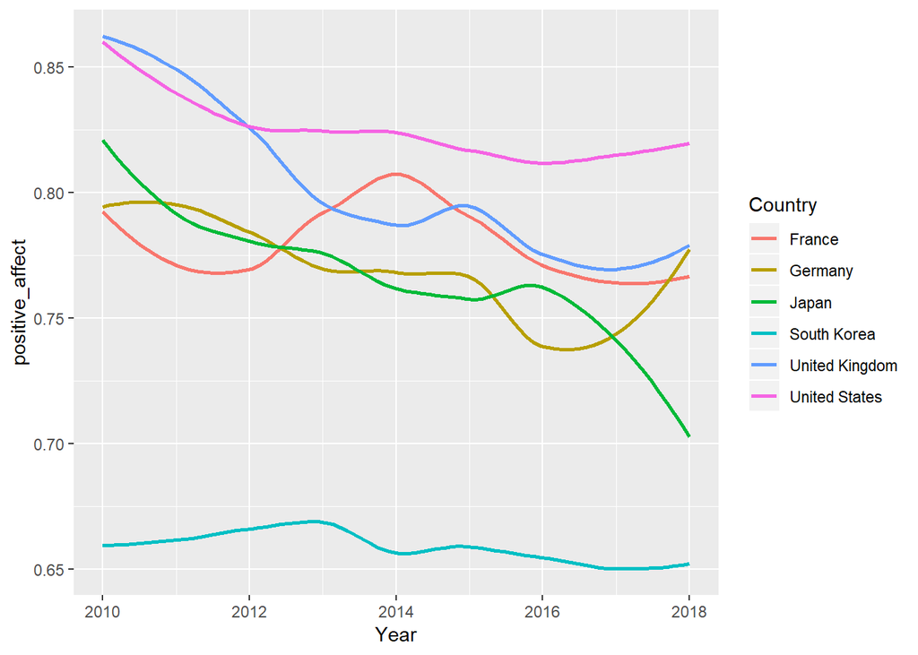

```r
country_df %>%
  filter(Country == "France" | Country == "Germany" | Country == "Japan" | Country == "South Korea" | Country == "United Kingdom" | Country == "United States" ) %>%
  ggplot(mapping = aes(x = Year, y = positive_affect, group_by(Year), color = Country)) +
  geom_smooth(size = 1, se = FALSE)
```

Developing Countries:

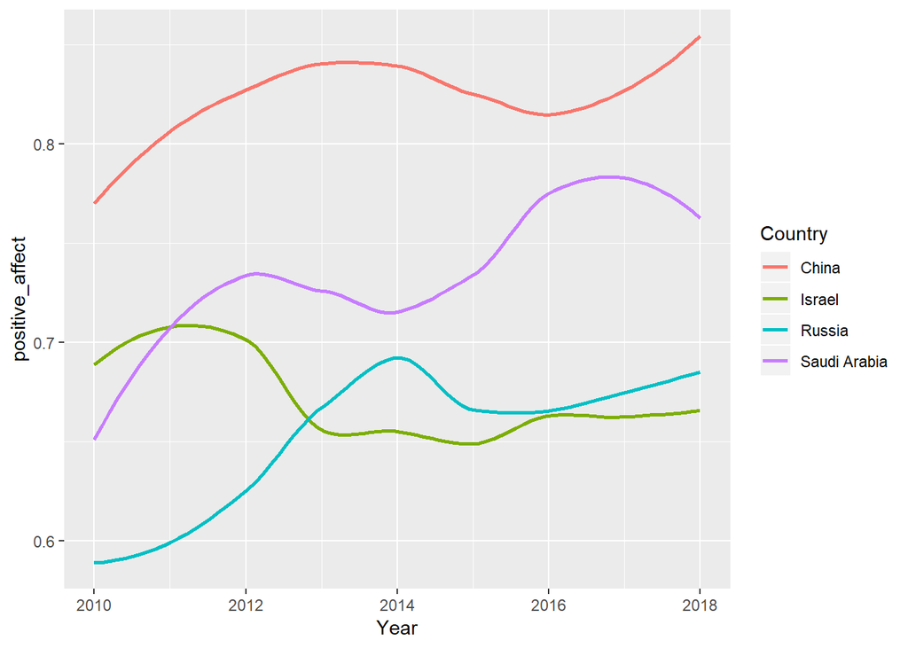

```r
country_df %>%
  filter(Country == "China" | Country == "Israel" | Country == "Russia" | Country == "Saudi Arabia" ) %>%
  ggplot(mapping = aes(x = Year, y = positive_affect, group_by(Year), color = Country)) +
  geom_smooth(size = 1, se = FALSE)
```

# Some Interesting trends to look at

# Positive Affect vs Life Expectancy

Below I plotted the positive affect vs life expectancy to see if a country’s life expectancy impacts the citizen’s happiness

Top 10 powerful countries:

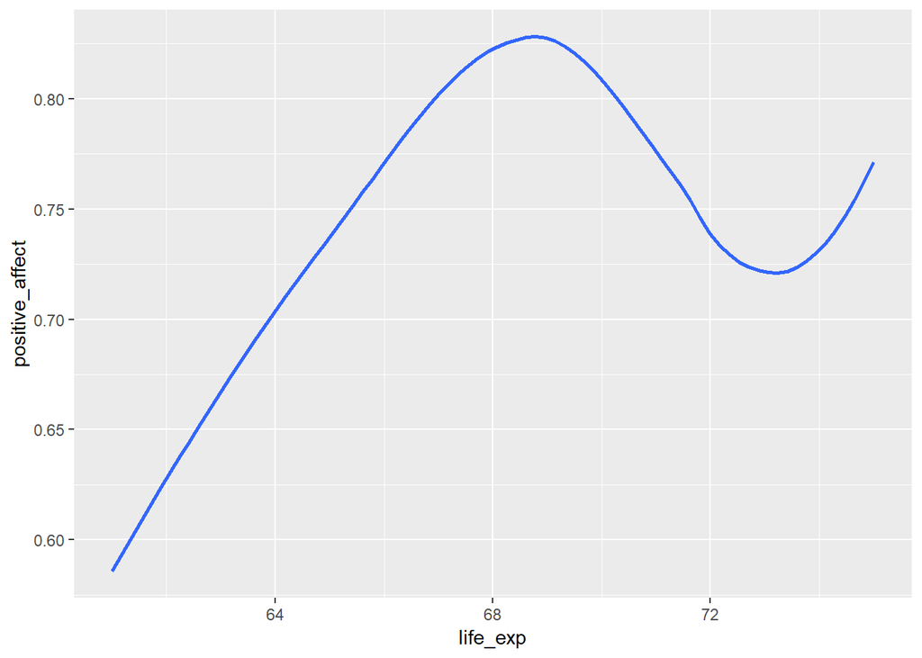

```r
country_df %>%
  ggplot(mapping = aes(x = life_exp, y = positive_affect)) +
  geom_smooth(size = 1, se = FALSE)
```

All of the countries:

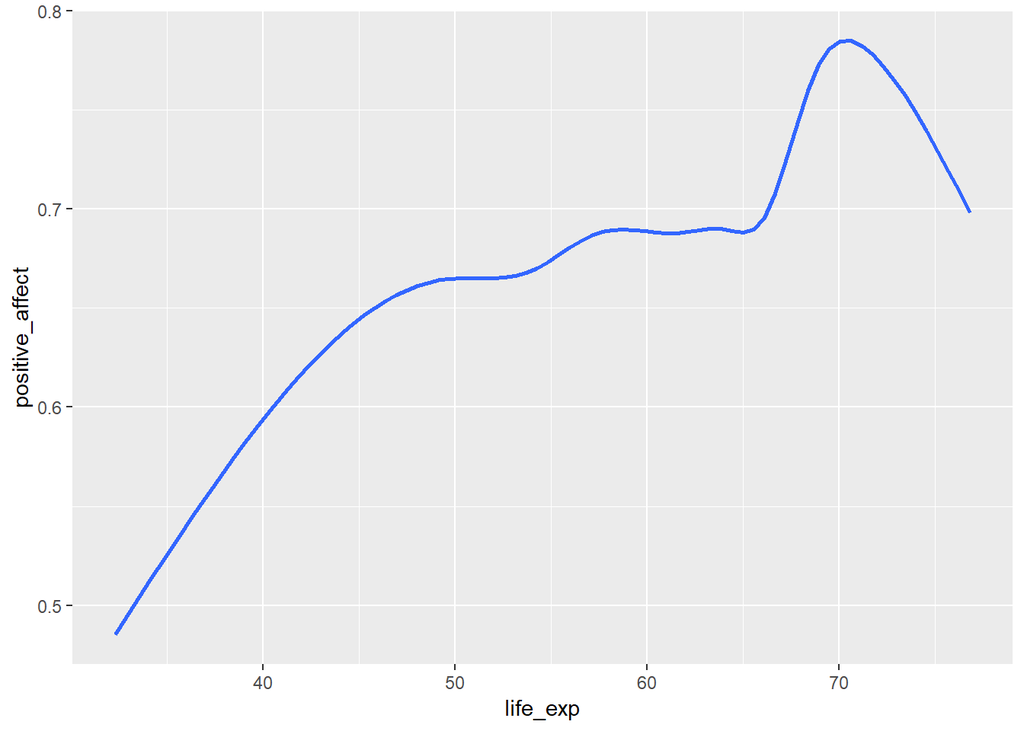

```r
select_df %>%
  ggplot(mapping = aes(x = life_exp, y = positive_affect)) +
  geom_smooth(size = 1, se = FALSE)
```

I anticipated that the higher the life expectancy, the higher the level of happiness. but the happiness rating peaks at the life expectancy of 70 and declines after that which I found interesting.

# Positive Affect vs Generosity

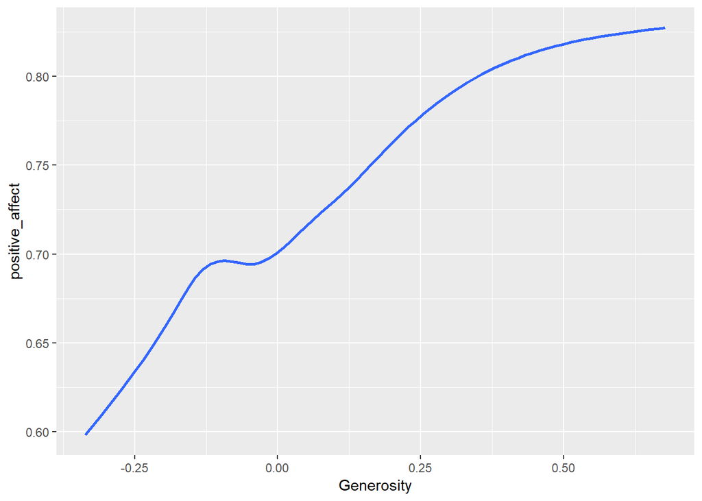

```r
select_df%>%
  ggplot(mapping = aes(x = Generosity, y = positive_affect)) +
  geom_smooth(size = 1, se = FALSE)
```

As expected, the trend for this is the higher the generosity, higher the happiness.

# Positive Affect vs Corruption

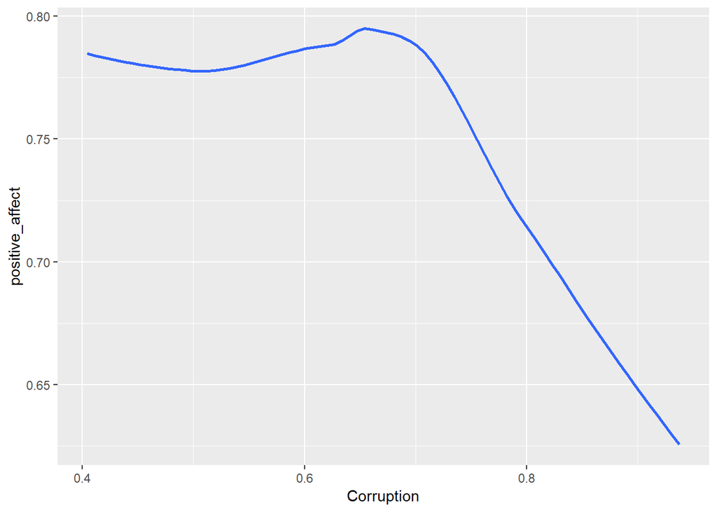

```r
country_df%>%
  ggplot(mapping = aes(x = Corruption, y = positive_affect)) +
  geom_smooth(size = 1, se = FALSE)
```

The trend appears the higher the corruption, lower the happiness rating.

# Hypothesis Testing:

Let’s take another look at the evolution of Happiness for the top 10 most powerful countries and see if we can fit a linear regression model to test if there is a relationship between year and happiness

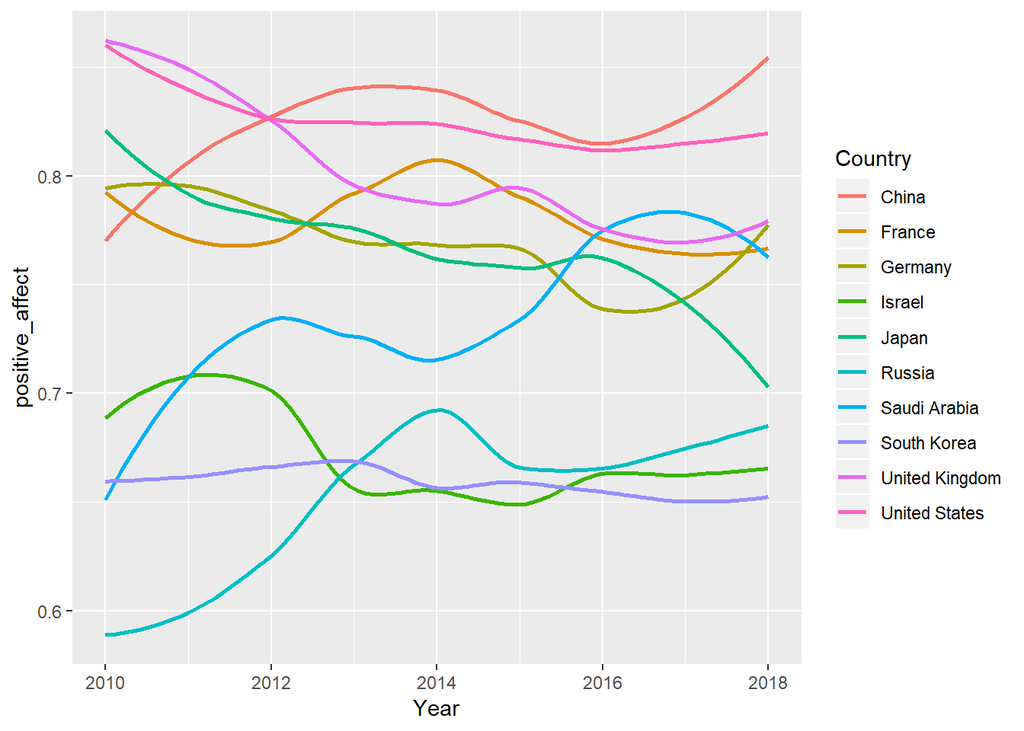

```r
country_df %>%
  ggplot(mapping = aes(x = Year, y = positive_affect, group_by(Year), color = Country)) +
  geom_smooth(size = 1, se = FALSE)
```

Since we can see in the plot that each Country has a different trend, we will include an interaction term for Country and Year.

```r
library(ISLR)
library(tidyverse)
library(broom)

mdl <- lm(positive_affect~Year+Country+Country:Year, data=country_df)

summary(mdl)
```

```
##
## Call:
## lm(formula = positive_affect ~ Year + Country + Country:Year,
##     data = country_df)
##
## Residuals:
##       Min        1Q    Median        3Q       Max
## -0.067654 -0.016601  0.000698  0.016527  0.049458
##
## Coefficients:
##                              Estimate Std. Error t value Pr(>|t|)
## (Intercept)                -10.869665   6.305899  -1.724 0.089171 .
## Year                         0.005806   0.003131   1.854 0.067913 .
## CountryFrance               15.774242   8.917888   1.769 0.081278 .
## CountryGermany              22.916999   8.917888   2.570 0.012308 *
## CountryIsrael               22.620152   8.917888   2.536 0.013430 *
## CountryJapan                33.801155   8.917888   3.790 0.000316 ***
## CountryRussia              -12.424413   8.917888  -1.393 0.167967
## CountrySaudi Arabia        -13.877429   8.917888  -1.556 0.124186
## CountrySouth Korea          14.947393   8.917888   1.676 0.098177 .
## CountryUnited Kingdom       34.859315   8.917888   3.909 0.000212 ***
## CountryUnited States        20.639151   8.917888   2.314 0.023588 *
## Year:CountryFrance          -0.007854   0.004428  -1.774 0.080475 .
## Year:CountryGermany         -0.011405   0.004428  -2.576 0.012120 *
## Year:CountryIsrael          -0.011307   0.004428  -2.553 0.012847 *
## Year:CountryJapan           -0.016812   0.004428  -3.797 0.000309 ***
## Year:CountryRussia           0.006084   0.004428   1.374 0.173825
## Year:CountrySaudi Arabia     0.006845   0.004428   1.546 0.126625
## Year:CountrySouth Korea     -0.007504   0.004428  -1.695 0.094588 .
## Year:CountryUnited Kingdom  -0.017318   0.004428  -3.911 0.000210 ***
## Year:CountryUnited States   -0.010246   0.004428  -2.314 0.023611 *
## ---
## Signif. codes:  0 '***' 0.001 '**' 0.01 '*' 0.05 '.' 0.1 ' ' 1
##
## Residual standard error: 0.02425 on 70 degrees of freedom
## Multiple R-squared:  0.9072, Adjusted R-squared:  0.8821
## F-statistic: 36.03 on 19 and 70 DF,  p-value: < 2.2e-16
```

```r
mdl_stats <- mdl %>%
  tidy()

mdl_stats
```

| term | estimate | std.error | statistic | p.value |
| --- | --- | --- | --- | --- |
| (Intercept) | -10.869665163 | 6.305899261 | -1.723730 | 0.0891710097 |
| Year | 0.005805774 | 0.003131030 | 1.854270 | 0.0679133653 |
| CountryFrance | 15.774241711 | 8.917888258 | 1.768832 | 0.0812782971 |
| CountryGermany | 22.916998697 | 8.917888258 | 2.569779 | 0.0123077267 |
| CountryIsrael | 22.620152303 | 8.917888258 | 2.536492 | 0.0134298160 |
| CountryJapan | 33.801155245 | 8.917888258 | 3.790264 | 0.0003156129 |
| CountryRussia | -12.424412796 | 8.917888258 | -1.393201 | 0.1679674502 |
| CountrySaudi Arabia | -13.877428803 | 8.917888258 | -1.556134 | 0.1241861861 |
| CountrySouth Korea | 14.947392934 | 8.917888258 | 1.676114 | 0.0981772404 |
| CountryUnited Kingdom | 34.859314622 | 8.917888258 | 3.908920 | 0.0002117193 |

[output cut: 10 more lines]

Now for each country we can look at their P values to see if we reject the null hypothesis of no relationship between year and Happiness.

We reject the nul hypothesis if our p value is less than $\alpha = 0.05$

France: p = 0.0812782971 $\nless$ 0.05 So we DO NOT reject the hypothesis

Germany: p = 0.0123077267 $\lt$ 0.05 so we reject

Israel: p = 0.0134298160 $\lt$ 0.05 so we reject

Japan: p = 0.0003156129 $\lt$ 0.05 so we reject

Russia: p = 0.1679674502 $\nless$ 0.05 so we DO NOT reject

Saudia Arabia: p = 0.1241861861 $\nless$ 0.05 so we DO NOT reject

South Korea: p = 0.0981772404 $\nless$ 0.05 so we DO NOT reject

United Kingdom: p = 0.0002117193 $\lt$ 0.05 so we reject

United States: p = 0.0235877448 $\lt$ 0.05 so we reject